Brianna Cabrera

```r
library(tidyverse)
library(nycflights13)
```

## 13.2.1 Exercises

### 1

You would need the `airports`,`planes`, and `flights` variables. The two tables you would need to combine are `airports` and `flights`.

### 2

```r
colnames(weather)
```

```
 [1] "origin"     "year"
 [3] "month"      "day"
 [5] "hour"       "temp"
 [7] "dewp"       "humid"
 [9] "wind_dir"   "wind_speed"
[11] "wind_gust"  "precip"
[13] "pressure"   "visib"
[15] "time_hour"
```

```r
colnames(airports)
```

```
[1] "faa"   "name"  "lat"   "lon"
[5] "alt"   "tz"    "dst"   "tzone"
```

The two tables can be matches by the variables `origin` in `weather` and `faa` in `airports`.

### 3

It would allow us to match the weather to different destinations as well.

### 4

To represent that data as a data frame, we can create a table that contains the information of the special dates. The primary keys of that table would be `year`, `month`, and `day`.

## 13.3.1Exercises

### 1

```r
flights %>%
  mutate(index = row_number()) %>%
  select(index, everything())
```

| index | year | month | day | dep_time | sched_dep_time | dep_delay | arr_time | sched_arr_time | arr_delay | carrier | flight | tailnum | origin | dest | air_time | distance | hour | minute | time_hour |
| --- | --- | --- | --- | --- | --- | --- | --- | --- | --- | --- | --- | --- | --- | --- | --- | --- | --- | --- | --- |
| 1 | 2013 | 1 | 1 | 517 | 515 | 2 | 830 | 819 | 11 | UA | 1545 | N14228 | EWR | IAH | 227 | 1400 | 5 | 15 | 2013-01-01 05:00:00 |
| 2 | 2013 | 1 | 1 | 533 | 529 | 4 | 850 | 830 | 20 | UA | 1714 | N24211 | LGA | IAH | 227 | 1416 | 5 | 29 | 2013-01-01 05:00:00 |
| 3 | 2013 | 1 | 1 | 542 | 540 | 2 | 923 | 850 | 33 | AA | 1141 | N619AA | JFK | MIA | 160 | 1089 | 5 | 40 | 2013-01-01 05:00:00 |
| 4 | 2013 | 1 | 1 | 544 | 545 | -1 | 1004 | 1022 | -18 | B6 | 725 | N804JB | JFK | BQN | 183 | 1576 | 5 | 45 | 2013-01-01 05:00:00 |
| 5 | 2013 | 1 | 1 | 554 | 600 | -6 | 812 | 837 | -25 | DL | 461 | N668DN | LGA | ATL | 116 | 762 | 6 | 0 | 2013-01-01 06:00:00 |
| 6 | 2013 | 1 | 1 | 554 | 558 | -4 | 740 | 728 | 12 | UA | 1696 | N39463 | EWR | ORD | 150 | 719 | 5 | 58 | 2013-01-01 05:00:00 |
| 7 | 2013 | 1 | 1 | 555 | 600 | -5 | 913 | 854 | 19 | B6 | 507 | N516JB | EWR | FLL | 158 | 1065 | 6 | 0 | 2013-01-01 06:00:00 |
| 8 | 2013 | 1 | 1 | 557 | 600 | -3 | 709 | 723 | -14 | EV | 5708 | N829AS | LGA | IAD | 53 | 229 | 6 | 0 | 2013-01-01 06:00:00 |
| 9 | 2013 | 1 | 1 | 557 | 600 | -3 | 838 | 846 | -8 | B6 | 79 | N593JB | JFK | MCO | 140 | 944 | 6 | 0 | 2013-01-01 06:00:00 |
| 10 | 2013 | 1 | 1 | 558 | 600 | -2 | 753 | 745 | 8 | AA | 301 | N3ALAA | LGA | ORD | 138 | 733 | 6 | 0 | 2013-01-01 06:00:00 |

[output cut: 990 more lines]

### 2

1. The primary keys for `Lahman::Batting` are `playerID`, `yearID`, `stint`, `teamID`, and `lgID`.

```r
Lahman::Batting %>%
  group_by(playerID, yearID, stint, teamID, lgID) %>%
  mutate(n = n()) %>%
  filter(n > 1) %>%
  nrow()
```

```
[1] 0
```

2. The primary keys for `babynames::babynames` are `year`, `sex`, `name`.

```r
babynames::babynames %>%
  group_by(year, sex, name) %>%
  mutate(n = n()) %>%
  filter(n > 1) %>%
  nrow()
```

```
[1] 0
```

```r
#install.packages("nasaweather")
library(nasaweather)
nasaweather::atmos %>%
  group_by(lat, long, year, month) %>%
  mutate(n = n()) %>%
  filter(n > 1) %>%
  nrow()
```

```
[1] 0
```

The primary keys for `nasaweather::atoms` are `lat`, `long`, `year`, and `month`.

```r
#install.packages("fueleconomy")
library(fueleconomy)
fueleconomy::vehicles %>%
  group_by(id) %>%
  mutate(n = n()) %>%
  filter(n > 1) %>%
  nrow()
```

```
[1] 0
```

```r
install.packages("diamonds")
library(diamonds)
```

```
Error in library(diamonds) : there is no package called ‘diamonds’
```

Couldn’t load data set.

### 3

```r
install.packages("Lahamn")
library(Lahman)
colnames(Lahamn::batting)
```

```
Error in loadNamespace(name) : there is no package called ‘Lahamn’
```

Package not available.

## 13.4.6 Exercises

### 1

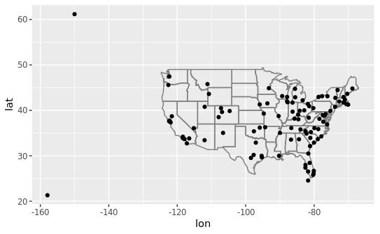

```r
airports %>%
  semi_join(flights, c("faa" = "dest")) %>%
  ggplot(aes(lon, lat)) +
    borders("state") +
    geom_point() +
    coord_quickmap()
```

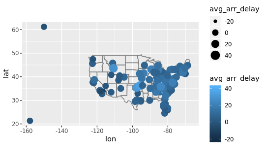

```r
flights %>% group_by(dest) %>%
  summarize(avg_arr_delay = mean(arr_delay, na.rm = TRUE)) %>%
  left_join(airports, by = c('dest' = 'faa')) %>%
  ggplot(aes(x = lon, y = lat, size = avg_arr_delay, color = avg_arr_delay)) +
  borders('state') +
  geom_point() +
  coord_quickmap()
```

### 2

```r
flights %>%
  left_join(airports, by = c('dest' = 'faa')) %>%
  left_join(airports, by = c('origin' = 'faa'), suffix = c('.dest', '.origin')) %>%
  select(dest, origin, contains('lat'), contains('lon'))
```

| dest | origin | lat.dest | lat.origin | lon.dest | lon.origin |
| --- | --- | --- | --- | --- | --- |
| IAH | EWR | 29.98443 | 40.69250 | -95.34144 | -74.16867 |
| IAH | LGA | 29.98443 | 40.77725 | -95.34144 | -73.87261 |
| MIA | JFK | 25.79325 | 40.63975 | -80.29056 | -73.77893 |
| BQN | JFK | NA | 40.63975 | NA | -73.77893 |
| ATL | LGA | 33.63672 | 40.77725 | -84.42807 | -73.87261 |
| ORD | EWR | 41.97860 | 40.69250 | -87.90484 | -74.16867 |
| FLL | EWR | 26.07258 | 40.69250 | -80.15275 | -74.16867 |
| IAD | LGA | 38.94453 | 40.77725 | -77.45581 | -73.87261 |
| MCO | JFK | 28.42939 | 40.63975 | -81.30899 | -73.77893 |
| ORD | LGA | 41.97860 | 40.77725 | -87.90484 | -73.87261 |

[output cut: 990 more lines]

### 3

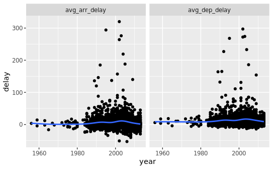

```r
flights %>% group_by(tailnum) %>%
  summarise(avg_dep_delay = mean(dep_delay, na.rm = TRUE),
            avg_arr_delay = mean(arr_delay, na.rm = TRUE)) %>%
  gather(key = 'mode', value = 'delay', 2:3) %>%
  left_join(planes, by = 'tailnum') %>%
  ggplot(mapping = aes(x = year, y = delay)) +
  geom_point() +
  geom_smooth(se = FALSE) +
  facet_grid(.~mode)
```

It’s hard to make a comparison.

### 4

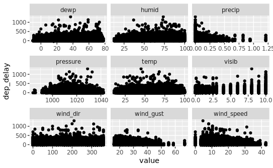

```r
flights %>%
  left_join(weather, by = c('year','month','day','hour','origin')) %>%
  gather(key = 'condition', value = 'value', temp:visib) %>%
  filter(!is.na(dep_delay)) %>%
  ggplot(mapping = aes(x = value, y = dep_delay)) +
  geom_point() +
  facet_wrap(~condition, ncol = 3, scale = 'free_x')
```

There is not any strong correlation.

## 13.5.1 Exercises

### 1

```r
flights %>%
  filter(is.na(tailnum))
```

| year | month | day | dep_time | sched_dep_time | dep_delay | arr_time | sched_arr_time | arr_delay | carrier | flight | tailnum | origin | dest | air_time | distance | hour | minute | time_hour |
| --- | --- | --- | --- | --- | --- | --- | --- | --- | --- | --- | --- | --- | --- | --- | --- | --- | --- | --- |
| 2013 | 1 | 2 | NA | 1545 | NA | NA | 1910 | NA | AA | 133 | NA | JFK | LAX | NA | 2475 | 15 | 45 | 2013-01-02 15:00:00 |
| 2013 | 1 | 2 | NA | 1601 | NA | NA | 1735 | NA | UA | 623 | NA | EWR | ORD | NA | 719 | 16 | 1 | 2013-01-02 16:00:00 |
| 2013 | 1 | 3 | NA | 857 | NA | NA | 1209 | NA | UA | 714 | NA | EWR | MIA | NA | 1085 | 8 | 57 | 2013-01-03 08:00:00 |
| 2013 | 1 | 3 | NA | 645 | NA | NA | 952 | NA | UA | 719 | NA | EWR | DFW | NA | 1372 | 6 | 45 | 2013-01-03 06:00:00 |
| 2013 | 1 | 4 | NA | 845 | NA | NA | 1015 | NA | 9E | 3405 | NA | JFK | DCA | NA | 213 | 8 | 45 | 2013-01-04 08:00:00 |
| 2013 | 1 | 4 | NA | 1830 | NA | NA | 2044 | NA | 9E | 3716 | NA | EWR | DTW | NA | 488 | 18 | 30 | 2013-01-04 18:00:00 |
| 2013 | 1 | 5 | NA | 840 | NA | NA | 1001 | NA | 9E | 3422 | NA | JFK | BOS | NA | 187 | 8 | 40 | 2013-01-05 08:00:00 |
| 2013 | 1 | 7 | NA | 820 | NA | NA | 958 | NA | 9E | 3317 | NA | JFK | BUF | NA | 301 | 8 | 20 | 2013-01-07 08:00:00 |
| 2013 | 1 | 8 | NA | 1645 | NA | NA | 1838 | NA | US | 123 | NA | EWR | CLT | NA | 529 | 16 | 45 | 2013-01-08 16:00:00 |
| 2013 | 1 | 9 | NA | 755 | NA | NA | 1012 | NA | 9E | 4023 | NA | EWR | CVG | NA | 569 | 7 | 55 | 2013-01-09 07:00:00 |

[output cut: 990 more lines]

For a flight to have a missing `tailnum` means that that flight was cancelled.

```r
flights %>%
  anti_join(planes, by = 'tailnum') %>%
  group_by(carrier) %>%
  summarize(n = n()) %>%
  arrange(desc(n))
```

| carrier | n |
| --- | --- |
| MQ | 25397 |
| AA | 22558 |
| UA | 1693 |
| 9E | 1044 |
| B6 | 830 |
| US | 699 |
| FL | 187 |
| DL | 110 |
| F9 | 50 |
| WN | 38 |

### 2

```r
flights %>%
  semi_join(count(flights, tailnum) %>% filter(n >= 100))
```

| year | month | day | dep_time | sched_dep_time | dep_delay | arr_time | sched_arr_time | arr_delay | carrier | flight | tailnum | origin | dest | air_time | distance | hour | minute | time_hour |
| --- | --- | --- | --- | --- | --- | --- | --- | --- | --- | --- | --- | --- | --- | --- | --- | --- | --- | --- |
| 2013 | 1 | 1 | 517 | 515 | 2 | 830 | 819 | 11 | UA | 1545 | N14228 | EWR | IAH | 227 | 1400 | 5 | 15 | 2013-01-01 05:00:00 |
| 2013 | 1 | 1 | 533 | 529 | 4 | 850 | 830 | 20 | UA | 1714 | N24211 | LGA | IAH | 227 | 1416 | 5 | 29 | 2013-01-01 05:00:00 |
| 2013 | 1 | 1 | 544 | 545 | -1 | 1004 | 1022 | -18 | B6 | 725 | N804JB | JFK | BQN | 183 | 1576 | 5 | 45 | 2013-01-01 05:00:00 |
| 2013 | 1 | 1 | 554 | 558 | -4 | 740 | 728 | 12 | UA | 1696 | N39463 | EWR | ORD | 150 | 719 | 5 | 58 | 2013-01-01 05:00:00 |
| 2013 | 1 | 1 | 555 | 600 | -5 | 913 | 854 | 19 | B6 | 507 | N516JB | EWR | FLL | 158 | 1065 | 6 | 0 | 2013-01-01 06:00:00 |
| 2013 | 1 | 1 | 557 | 600 | -3 | 709 | 723 | -14 | EV | 5708 | N829AS | LGA | IAD | 53 | 229 | 6 | 0 | 2013-01-01 06:00:00 |
| 2013 | 1 | 1 | 557 | 600 | -3 | 838 | 846 | -8 | B6 | 79 | N593JB | JFK | MCO | 140 | 944 | 6 | 0 | 2013-01-01 06:00:00 |
| 2013 | 1 | 1 | 558 | 600 | -2 | 849 | 851 | -2 | B6 | 49 | N793JB | JFK | PBI | 149 | 1028 | 6 | 0 | 2013-01-01 06:00:00 |
| 2013 | 1 | 1 | 558 | 600 | -2 | 853 | 856 | -3 | B6 | 71 | N657JB | JFK | TPA | 158 | 1005 | 6 | 0 | 2013-01-01 06:00:00 |
| 2013 | 1 | 1 | 558 | 600 | -2 | 923 | 937 | -14 | UA | 1124 | N53441 | EWR | SFO | 361 | 2565 | 6 | 0 | 2013-01-01 06:00:00 |

[output cut: 990 more lines]

### 3

```r
ten_common <-
  fueleconomy::common %>%
  ungroup() %>%
  arrange(-n) %>%
  top_n(10, n)
fueleconomy::vehicles %>%
  semi_join(ten_common)
```

| id | make | model | year | class | trans | drive | cyl | displ | fuel | hwy | cty |
| --- | --- | --- | --- | --- | --- | --- | --- | --- | --- | --- | --- |
| 1182 | Chevrolet | Camaro | 1985 | Subcompact Cars | Automatic 4-spd | Rear-Wheel Drive | 6 | 2.8 | Regular | 24 | 16 |
| 1183 | Chevrolet | Camaro | 1985 | Subcompact Cars | Manual 5-spd | Rear-Wheel Drive | 6 | 2.8 | Regular | 24 | 15 |
| 1184 | Chevrolet | Camaro | 1985 | Subcompact Cars | Automatic 4-spd | Rear-Wheel Drive | 8 | 5.0 | Regular | 20 | 15 |
| 62 | Chevrolet | Camaro | 1985 | Subcompact Cars | Manual 5-spd | Rear-Wheel Drive | 4 | 2.5 | Regular | 30 | 19 |
| 63 | Chevrolet | Camaro | 1985 | Subcompact Cars | Automatic 4-spd | Rear-Wheel Drive | 6 | 2.8 | Regular | 24 | 16 |
| 64 | Chevrolet | Camaro | 1985 | Subcompact Cars | Manual 5-spd | Rear-Wheel Drive | 6 | 2.8 | Regular | 25 | 16 |
| 65 | Chevrolet | Camaro | 1985 | Subcompact Cars | Automatic 4-spd | Rear-Wheel Drive | 8 | 5.0 | Regular | 20 | 14 |
| 66 | Chevrolet | Camaro | 1985 | Subcompact Cars | Manual 5-spd | Rear-Wheel Drive | 8 | 5.0 | Regular | 22 | 14 |
| 67 | Chevrolet | Camaro | 1985 | Subcompact Cars | Automatic 4-spd | Rear-Wheel Drive | 8 | 5.0 | Regular | 20 | 15 |
| 1755 | Chevrolet | Camaro | 1986 | Subcompact Cars | Manual 5-spd | Rear-Wheel Drive | 4 | 2.5 | Regular | 29 | 21 |

[output cut: 990 more lines]

### 4

```r
fn <-flights %>%
  group_by(month, day) %>%
  summarize(avg_delay = sum(arr_delay + dep_delay, na.rm = TRUE)) %>%
  mutate(twoday_delay = avg_delay + lag(avg_delay)) %>%
  arrange(-twoday_delay)
wea <-weather %>%
  group_by(month, day) %>%
  summarize_at(vars(humid, precip, temp), mean, na.rm = TRUE)
fn %>%
  left_join(wea) %>%
  arrange(twoday_delay)
```

| month | day | avg_delay | twoday_delay | humid | precip | temp |
| --- | --- | --- | --- | --- | --- | --- |
| 9 | 6 | -17611 | -32992 | 45.52153 | 0.0000000000 | 64.10500 |
| 10 | 2 | -13615 | -31911 | 58.91444 | 0.0000000000 | 73.34750 |
| 9 | 7 | -14153 | -31764 | 50.52847 | 0.0000000000 | 68.67500 |
| 9 | 5 | -15381 | -29234 | 48.80056 | 0.0000000000 | 71.90250 |
| 9 | 8 | -8526 | -22679 | 51.15819 | 0.0000000000 | 73.26500 |
| 9 | 18 | -9503 | -19423 | 55.35139 | 0.0000000000 | 61.15750 |
| 9 | 9 | -10778 | -19304 | 55.04167 | 0.0000000000 | 65.21500 |
| 8 | 26 | -8529 | -16868 | 59.14417 | 0.0004166667 | 75.49500 |
| 8 | 27 | -8109 | -16638 | 66.33194 | 0.0008333333 | 78.93250 |
| 9 | 10 | -5251 | -16029 | 72.98986 | 0.0000000000 | 76.31250 |

[output cut: 355 more lines]

### 5

It shows flights whose destinations are not included in the `airports` database. It shows the airport names and locations that the flights from `flights` are not flying to.

### 6

```r
flights %>%
  select(carrier, tailnum) %>%
  group_by(tailnum) %>%
  summarize(n = length(unique(carrier))) %>%
  filter(n > 1)
```

| tailnum | n |
| --- | --- |
| N146PQ | 2 |
| N153PQ | 2 |
| N176PQ | 2 |
| N181PQ | 2 |
| N197PQ | 2 |
| N200PQ | 2 |
| N228PQ | 2 |
| N232PQ | 2 |
| N933AT | 2 |
| N935AT | 2 |

[output cut: 8 more lines]

There were plants that were flown by over 1 carrier.